# *cSEAdb* User’s Guide

# Generate signal tracks for the queried SE regions

In this section, we demo how to create ChIP-seq H3K27Ac data object in order to visualze SE signals.

First, the normalized bigwig files should be downloaded to local computer from our pre-documented repository.

```r
# Download the normalized bigwig files of NCI-60 cell lines
# Download links are located in data/bw_all_plinks.txt file
bw_links <- system.file("extdata","bw_all_plinks.txt",package="cSEAdb")
bw_download_link <- read.table(bw_links,sep="\t",header=F)
head(bw_download_link$V1)
```

```
#> [1] "https://data.cyverse.org/dav-anon/iplant/home/xiangliu817/se_database/merged_normalized_bw/786-0_normalized.bw"
#> [2] "https://data.cyverse.org/dav-anon/iplant/home/xiangliu817/se_database/merged_normalized_bw/A498_normalized.bw"
#> [3] "https://data.cyverse.org/dav-anon/iplant/home/xiangliu817/se_database/merged_normalized_bw/A549_normalized.bw"
#> [4] "https://data.cyverse.org/dav-anon/iplant/home/xiangliu817/se_database/merged_normalized_bw/ACHN_normalized.bw"
#> [5] "https://data.cyverse.org/dav-anon/iplant/home/xiangliu817/se_database/merged_normalized_bw/BT-549_normalized.bw"
#> [6] "https://data.cyverse.org/dav-anon/iplant/home/xiangliu817/se_database/merged_normalized_bw/CAKI-1_normalized.bw"
```

```r
# Create a bigwig list using the path of bigwig files
# Here is an example of path list for downloaded bigwig files
bw_dir <- system.file("extdata","example_bw",package="cSEAdb")
bw_path  <- list.files(bw_dir,full.names = T)
head(bw_path)
```

```
#> [1] "/Library/Frameworks/R.framework/Versions/4.2/Resources/library/cSEAdb/extdata/example_bw/786-0_dummy.bw"
#> [2] "/Library/Frameworks/R.framework/Versions/4.2/Resources/library/cSEAdb/extdata/example_bw/A498_dummy.bw"
#> [3] "/Library/Frameworks/R.framework/Versions/4.2/Resources/library/cSEAdb/extdata/example_bw/A549_dummy.bw"
#> [4] "/Library/Frameworks/R.framework/Versions/4.2/Resources/library/cSEAdb/extdata/example_bw/ACHN_dummy.bw"
#> [5] "/Library/Frameworks/R.framework/Versions/4.2/Resources/library/cSEAdb/extdata/example_bw/BT-549_dummy.bw"
#> [6] "/Library/Frameworks/R.framework/Versions/4.2/Resources/library/cSEAdb/extdata/example_bw/CAKI-1_dummy.bw"
```

Then, a data object (GRanges) can be generated to store the H3K27Ac signal tracks for the queried SE regions. Although, only cancers/cells in the NCI-60 are allowed to be queried above, visulization of signals of the queried SEs in other cell lines is allowed here. See below on how to add other bigwig files duing the data object preparation.

```r
# Select a plot region
plot_region <- "chr1:1156819-1178981"

# Extract cSEAdb information
search_db_table <- search_db(plot_region,
                             query_type="se_region",se_db=cSEAdb)

# User can also add other H3K27Ac bigwig files beyond the NCI-60 cell panel
usr_bigwig <- system.file("extdata","example_signal.bw",package="cSEAdb")

# Create bigwig GRange object for downstream plotting
bw_gr <- create_bw_gr(plot_region,c(bw_path,usr_bigwig),se_spec_table=search_db_table)
```

Next, users can filter or specify which cell lines to be plotted. For demo purpose, we only look into cell lines that the queried SEs show specificity (*specific*). We also manually add other cell lines (A549, MCF7) and a customized sample.

```r
# add hg38 genomes for gene tracks (optional)
library(TxDb.Hsapiens.UCSC.hg38.knownGene)

# Create plot object for gviz package with gene tracks
plot_object <- create_gviz_tracks(bw_gr_list=bw_gr$bw_gr,
                               cell="specific,A549,MCF7,example_signal.bw",
                               se_spec_table=search_db_table,
                               plot_region=plot_region,
                               txdb=TxDb.Hsapiens.UCSC.hg38.knownGene)

# Names of plot_object elements
names(plot_object)
```

```
#> [1] "htrack"       "atrack_ce"    "atrack_se"    "atrack_query" "gtrack"
#> [6] "plot_region"  "axistrack"
```

The data object includes the following 7 types of information to be plotted. Users can also customize which information to be included using Gviz package.

1. htrack: main bigwig tracks (must include).
2. atrack_ce: CE regions.
3. atrack_se: SE regions.
4. atrack_query: query regions.
5. gtrack: genomic tracks with gene information
6. plot_region: regions to be plotted.
7. axistrack: genome axis track indicating locations.

## Plot all tracks

Example to visualize with all types of information in the data object.

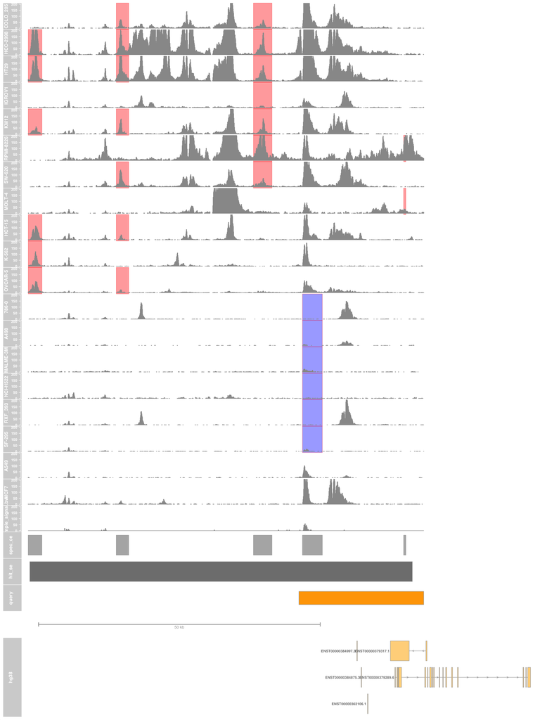

```r
# with the plotting object, users can customize which track to plot using gviz package
plotTracks(c(plot_object$htrack,
             plot_object$atrack_ce,
             plot_object$atrack_se,
             plot_object$atrack_query,
             plot_object$axistrack,
             plot_object$gtrack),
           size=10,
           cex.title = 0.8)
```

Example to visualize with the selected types of information in the data object.

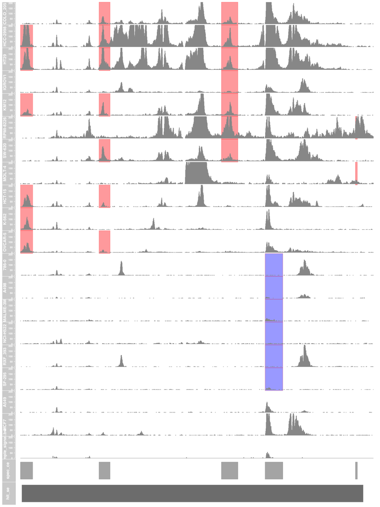

```r
# with the plotting object, users can customize which track to plot using gviz package
plotTracks(c(plot_object$htrack,
             plot_object$atrack_ce,
             plot_object$atrack_se),
           size=10,
           cex.title = 1)
```

# Generate chromosome maps

In this section, we demo how to generate chromosome maps of specific SEs/CEs using data from A549 cell line.

```r
# load tools
library(chromoMap)

# read cell spec chromosome file and chromosome size file
cell_spec <- readRDS(system.file("data","cell_spec_for_chr_plot.rds",package="cSEAdb"))
chrom_size <- read.table(system.file("extdata","hg38_chrom_loc_w_centromere.txt",package="cSEAdb"),
                         sep="\t",header=F)
head(chrom_size)
```

|  | V1 | V2 | V3 | V4 |
| --- | --- | --- | --- | --- |
| 1 | chr1 | 1 | 248956422 | 123400000 |
| 2 | chr2 | 1 | 242193529 | 93900000 |
| 3 | chr3 | 1 | 198295559 | 90900000 |
| 4 | chr4 | 1 | 190214555 | 50000000 |
| 5 | chr5 | 1 | 181538259 | 48800000 |
| 6 | chr6 | 1 | 170805979 | 59800000 |

```r
# Extract specificity information with A549
cell_spec_example <- cell_spec$A549

# Generate chromosome map with chromoMap package
chr_map <- chromoMap(list(chrom_size),list(cell_spec_example),
                          n_win.factor = 2,
                          # chr_width = 20,
                          chr_length = 6,
                          chr_color = "grey",
                          data_based_color_map = T,
                          data_type = "categorical",
                          legend = T,
                          lg_x = 200,
                          lg_y = 500,
                          title="A549",
                          text_font_size = c(16),
                          data_colors = list(c("firebrick3","lightskyblue","gold3")))
```

```
#> ********************************** __ __ ************
#> ** __**|__ * __* __ * __ __ * __ *|  |  |* __ * __ **
#> **|__**|  |*|  *|__|*|  |  |*|__|*|  |  |*|_ |*|__|**
#> ***********************************************|   **
#> OUTPUT:
#> Number of Chromosome sets: 1
#> Number of Chromosomes in set  1 : 23
#> Processing data..
#> Number of annotations in data set  1 : 1340
#> Visualizing..
```

```r
chr_map
```

[interactive chart not shown]